# Red neuronal

**Análisis del Problema** Hoy en día “El dinero plástico”, como también se le conoce, es bienvenido en la mayoría de los establecimientos comerciales de todas las categorías: hoteles, restaurantes, agencias de viajes, entre otros. Esta herramienta de crédito es un convenio entre una institución financiera (banco u otro tipo de compañía) y el prestatario (la persona titular del crédito, o sea tú), mediante la cual se pone un cupo de dinero disponible para que lo use a través de una tarjeta de crédito, cuyo posterior pago mensual esta sujeto a los gasto que se efectúe y la cantidad de cuotas a la que sea diferida la compra.

Se quiere predecir cuales clientes son aptos para la aprobación de una tarjeta de crédito.

**Entendimiento de los Datos**

```
Dominio   Descripción
A1:       b, a.
A2:       continuous.
A3:       continuous.
A4:       u, y, l, t.
A5:       g, p, gg.
A6:       c, d, cc, i, j, k, m, r, q, w, x, e, aa, ff.
A7:       v, h, bb, j, n, z, dd, ff, o.
A8:       continuous.
A9:       t, f.
A10:        t, f.
A11:        continuous.
A12:        t, f.
A13:        g, p, s.
A14:        continuous.
A15:        continuous.
A16:      +,-         (class attribute)
```

**Exploración de los Datos**

```r
#Cargar las librerías necesarias
library(lattice)
library(caTools)
library(ROCR)
library(neuralnet)
#Cargar el archivo a una variable que se llame crx usando la función read.csv
crx=read.csv(file = "datos/crx.data.txt",head=FALSE,sep=",",na.strings = '?')

crx$V1 <- factor(crx$V1)
crx$V4 <- factor(crx$V4)
crx$V5 <- factor(crx$V5)
crx$V6 <- factor(crx$V6)
crx$V7 <- factor(crx$V7)
crx$V10 <- factor(crx$V10)
crx$V12 <- factor(crx$V12)
crx$V13 <- factor(crx$V13)

crx$V16 <- as.character(crx$V16)
crx[crx$V16 == '+',]$V16 <- 'yes'
crx[crx$V16 == '-',]$V16 <- 'no'
crx$V16 <- factor(crx$V16)

#La estructura del conjunto de datos:
str(crx)
```

```
## 'data.frame':    690 obs. of  16 variables:
##  $ V1 : Factor w/ 2 levels "a","b": 2 1 1 2 2 2 2 1 2 2 ...
##  $ V2 : num  30.8 58.7 24.5 27.8 20.2 ...
##  $ V3 : num  0 4.46 0.5 1.54 5.62 ...
##  $ V4 : Factor w/ 3 levels "l","u","y": 2 2 2 2 2 2 2 2 3 3 ...
##  $ V5 : Factor w/ 3 levels "g","gg","p": 1 1 1 1 1 1 1 1 3 3 ...
##  $ V6 : Factor w/ 14 levels "aa","c","cc",..: 13 11 11 13 13 10 12 3 9 13 ...
##  $ V7 : Factor w/ 9 levels "bb","dd","ff",..: 8 4 4 8 8 8 4 8 4 8 ...
##  $ V8 : num  1.25 3.04 1.5 3.75 1.71 ...
##  $ V9 : Factor w/ 2 levels "f","t": 2 2 2 2 2 2 2 2 2 2 ...
##  $ V10: Factor w/ 2 levels "f","t": 2 2 1 2 1 1 1 1 1 1 ...
##  $ V11: int  1 6 0 5 0 0 0 0 0 0 ...
##  $ V12: Factor w/ 2 levels "f","t": 1 1 1 2 1 2 2 1 1 2 ...
##  $ V13: Factor w/ 3 levels "g","p","s": 1 1 1 1 3 1 1 1 1 1 ...
##  $ V14: int  202 43 280 100 120 360 164 80 180 52 ...
##  $ V15: int  0 560 824 3 0 0 31285 1349 314 1442 ...
##  $ V16: Factor w/ 2 levels "no","yes": 2 2 2 2 2 2 2 2 2 2 ...
```

```r
#Dividir el conjunto de datos en uno de entrenamiento y otro de pruebas:
set.seed(5768)
splt <- sample.split(crx$V16, SplitRatio = 0.7)
crx.entrenamiento <- crx[splt, ]
crx.prueba <- crx[!splt, ]

crx
```

| V1 | V2 | V3 | V4 | V5 | V6 | V7 | V8 | V9 | V10 | V11 | V12 | V13 | V14 | V15 | V16 |
| --- | --- | --- | --- | --- | --- | --- | --- | --- | --- | --- | --- | --- | --- | --- | --- |
| b | 30.83 | 0.000 | u | g | w | v | 1.250 | t | t | 1 | f | g | 202 | 0 | yes |
| a | 58.67 | 4.460 | u | g | q | h | 3.040 | t | t | 6 | f | g | 43 | 560 | yes |
| a | 24.50 | 0.500 | u | g | q | h | 1.500 | t | f | 0 | f | g | 280 | 824 | yes |
| b | 27.83 | 1.540 | u | g | w | v | 3.750 | t | t | 5 | t | g | 100 | 3 | yes |
| b | 20.17 | 5.625 | u | g | w | v | 1.710 | t | f | 0 | f | s | 120 | 0 | yes |
| b | 32.08 | 4.000 | u | g | m | v | 2.500 | t | f | 0 | t | g | 360 | 0 | yes |
| b | 33.17 | 1.040 | u | g | r | h | 6.500 | t | f | 0 | t | g | 164 | 31285 | yes |
| a | 22.92 | 11.585 | u | g | cc | v | 0.040 | t | f | 0 | f | g | 80 | 1349 | yes |
| b | 54.42 | 0.500 | y | p | k | h | 3.960 | t | f | 0 | f | g | 180 | 314 | yes |
| b | 42.50 | 4.915 | y | p | w | v | 3.165 | t | f | 0 | t | g | 52 | 1442 | yes |

[output cut: 680 more lines]

```r
set.seed(5768)
splt <- sample.split(crx$V16, SplitRatio = 0.7)
crx.entrenamiento <- crx[splt, ]
crx.prueba <- crx[!splt, ]
```

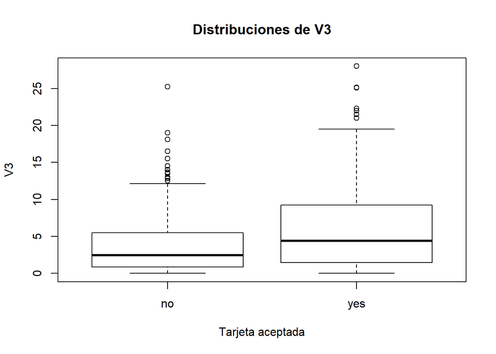

```r
boxplot(crx.entrenamiento$V3 ~ crx.entrenamiento$V16,
main = 'Distribuciones de V3',
ylab = 'V3',
xlab = 'Tarjeta aceptada')
```

Del gráfico anterior, podemos concluir que hubo valores variados entre los diferentes rangos del sí entre 0 y 10 y unos valores que están generando bastante ruido arriba de los 15. Y valores poco variados en el no, y con valores arriba del 10 que generan bastante ruido en los datos.

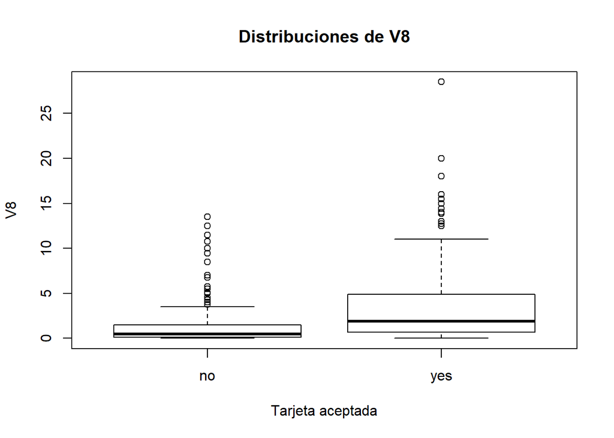

```r
boxplot(crx.entrenamiento$V8 ~ crx.entrenamiento$V16,
main = 'Distribuciones de V8',
ylab = 'V8',
xlab = 'Tarjeta aceptada')
```

Del gráfico anterior, podemos concluir que casi no hubo valores variados entre los diferentes rangos del sí y del no y los valores arriba del 5 en no y 10 arriba del si están generando bastante ruido.

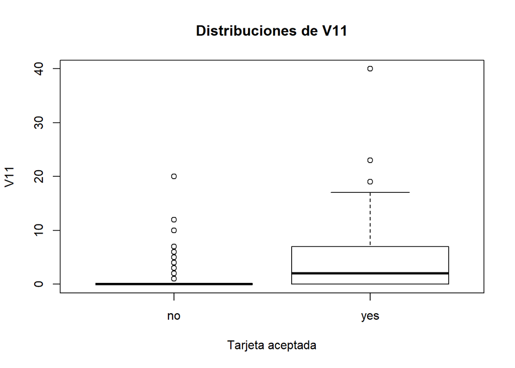

```r
boxplot(crx.entrenamiento$V11 ~ crx.entrenamiento$V16,
main = 'Distribuciones de V11',
ylab = 'V11',
xlab = 'Tarjeta aceptada')
```

Del gráfico anterior, podemos concluir que casi no hubo valores variados entre los diferentes rangos del no, y variados en el si casi hasta el valor 10.

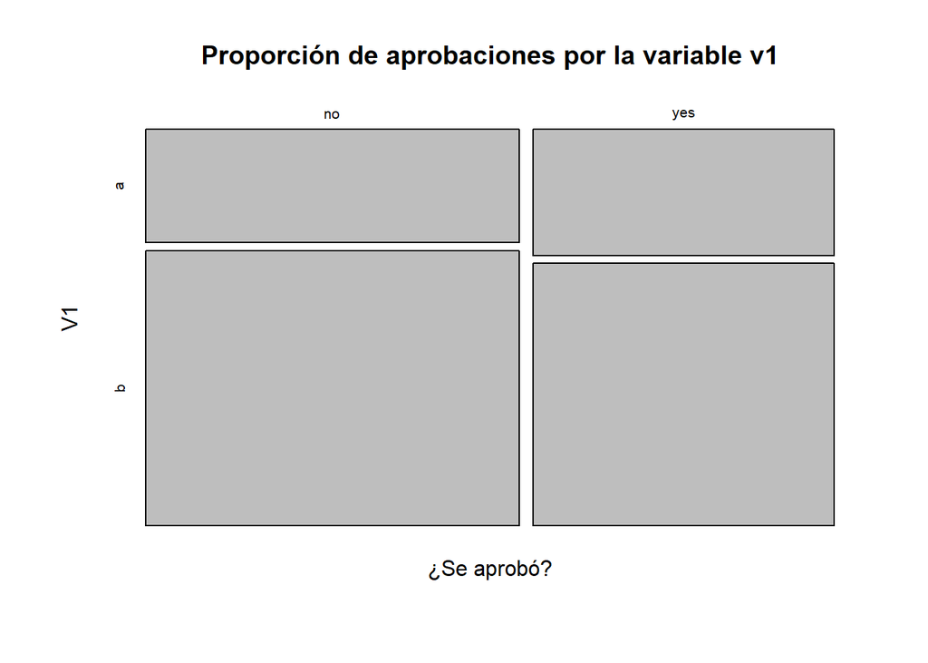

```r
mosaicplot(~crx.entrenamiento$V16 + crx.entrenamiento$V1,main="Proporción de aprobaciones por la variable v1",ylab="V1",xlab="¿Se aprobó?")
```

En el gráfico de mosaico arriba, podemos apreciar cómo hay un mayor número de observaciones de tipo B con la aprobación de la tarjeta de crédito, y como complemento el tipo A de menor aprobación

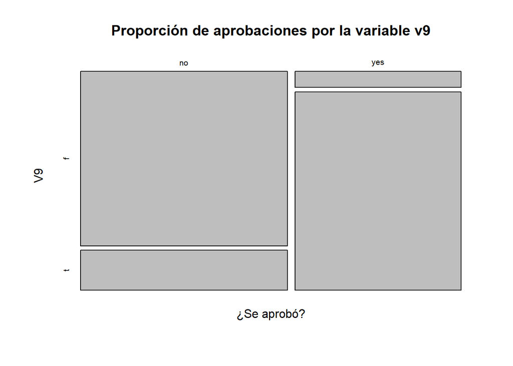

```r
mosaicplot(~crx.entrenamiento$V16 + crx.entrenamiento$V9,main="Proporción de aprobaciones por la variable v9",ylab="V9",xlab="¿Se aprobó?")
```

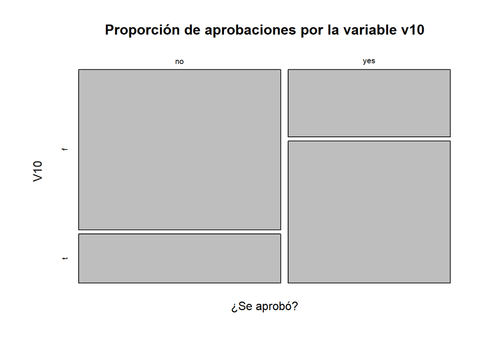

```r
mosaicplot(~crx.entrenamiento$V16 + crx.entrenamiento$V10,main="Proporción de aprobaciones por la variable v10",ylab="V10",xlab="¿Se aprobó?")
```

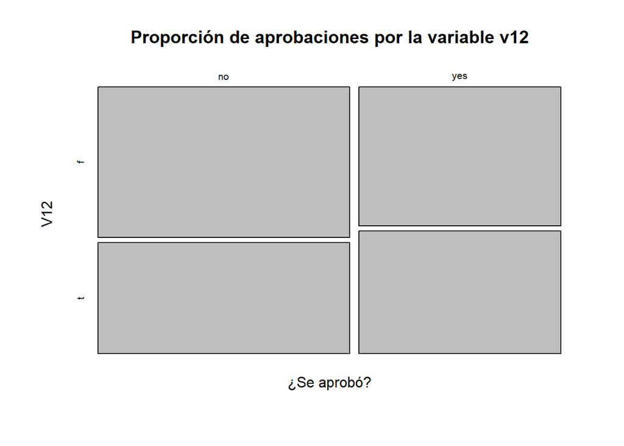

```r
mosaicplot(~crx.entrenamiento$V16 + crx.entrenamiento$V12,main="Proporción de aprobaciones por la variable v12",ylab="V12",xlab="¿Se aprobó?")
```

En el gráfico de mosaico arriba, podemos apreciar cómo hay un mayor número de observaciones de tipo F con la aprobación de la tarjeta de crédito, y como complemento el tipo T de menor aprobación

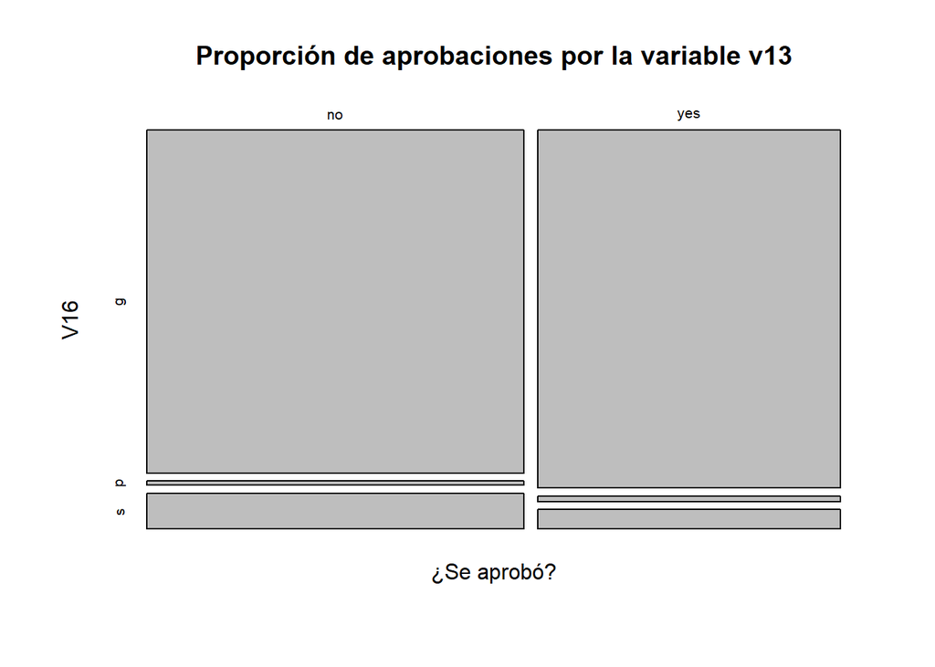

```r
mosaicplot(~crx.entrenamiento$V16 + crx.entrenamiento$V13,main="Proporción de aprobaciones por la variable v13",ylab="V16",xlab="¿Se aprobó?")
```

En el gráfico de mosaico arriba, podemos apreciar cómo hay un mayor número de observaciones de tipo G con la aprobación de la tarjeta de crédito, y como complemento el tipo S de menor aprobación y casi mínima aprobación en Tipo P.

**Modelo de Minería de Datos**

```r
m <- model.matrix(
   ~V16+ V1 + V2 + V3 + V4 + V5 + V6 + V7+ V8+ V9+ V10+ V11+ V12+ V13+ V14+ V15 ,
  data = crx.entrenamiento
)

crx.fit <- neuralnet(V16yes ~ V1b+V2 ,data = m,hidden =4,rep=1,linear.output=T)
```

Al ver los detalles del modelo 1:

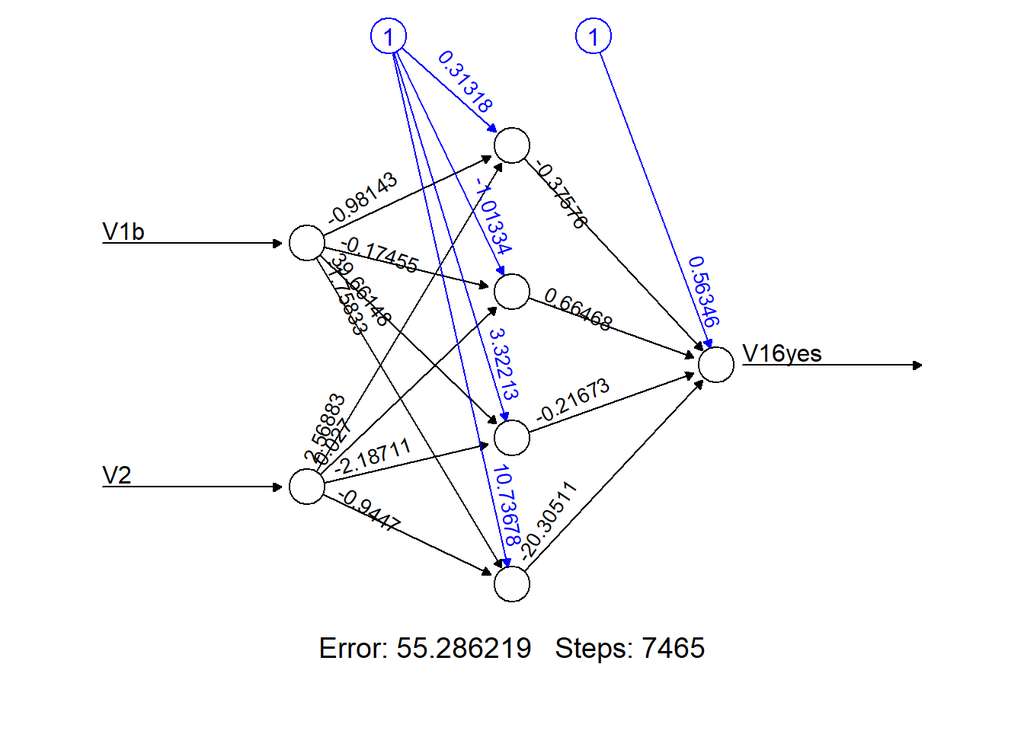

```r
plot(crx.fit,rep="best")
```

**Evaluación**

```r
mp <- model.matrix(
   ~V16+ V1 + V2 + V3 + V4 + V5 + V6 + V7+ V8+ V9+ V10+ V11+ V12+ V13+ V14+ V15 ,
  data = crx.prueba
)

predicciones.red <- neuralnet::compute(crx.fit,mp[,c("V1b","V2")])

results <- data.frame(actual = mp, prediction = predicciones.red$net.result)
results
```

|  | actual..Intercept. | actual.V16yes | actual.V1b | actual.V2 | actual.V3 | actual.V4u | actual.V4y | actual.V5gg | actual.V5p | actual.V6c | actual.V6cc | actual.V6d | actual.V6e | actual.V6ff | actual.V6i | actual.V6j | actual.V6k | actual.V6m | actual.V6q | actual.V6r | actual.V6w | actual.V6x | actual.V7dd | actual.V7ff | actual.V7h | actual.V7j | actual.V7n | actual.V7o | actual.V7v | … |
| --- | --- | --- | --- | --- | --- | --- | --- | --- | --- | --- | --- | --- | --- | --- | --- | --- | --- | --- | --- | --- | --- | --- | --- | --- | --- | --- | --- | --- | --- | --- |
| 1 | 1 | 1 | 1 | 30.83 | 0.000 | 1 | 0 | 0 | 0 | 0 | 0 | 0 | 0 | 0 | 0 | 0 | 0 | 0 | 0 | 0 | 1 | 0 | 0 | 0 | 0 | 0 | 0 | 0 | 1 | … |
| 2 | 1 | 1 | 0 | 58.67 | 4.460 | 1 | 0 | 0 | 0 | 0 | 0 | 0 | 0 | 0 | 0 | 0 | 0 | 0 | 1 | 0 | 0 | 0 | 0 | 0 | 1 | 0 | 0 | 0 | 0 | … |
| 3 | 1 | 1 | 0 | 24.50 | 0.500 | 1 | 0 | 0 | 0 | 0 | 0 | 0 | 0 | 0 | 0 | 0 | 0 | 0 | 1 | 0 | 0 | 0 | 0 | 0 | 1 | 0 | 0 | 0 | 0 | … |
| 15 | 1 | 1 | 0 | 45.83 | 10.500 | 1 | 0 | 0 | 0 | 0 | 0 | 0 | 0 | 0 | 0 | 0 | 0 | 0 | 1 | 0 | 0 | 0 | 0 | 0 | 0 | 0 | 0 | 0 | 1 | … |
| 21 | 1 | 1 | 1 | 25.00 | 11.250 | 1 | 0 | 0 | 0 | 1 | 0 | 0 | 0 | 0 | 0 | 0 | 0 | 0 | 0 | 0 | 0 | 0 | 0 | 0 | 0 | 0 | 0 | 0 | 1 | … |
| 23 | 1 | 1 | 0 | 47.75 | 8.000 | 1 | 0 | 0 | 0 | 1 | 0 | 0 | 0 | 0 | 0 | 0 | 0 | 0 | 0 | 0 | 0 | 0 | 0 | 0 | 0 | 0 | 0 | 0 | 1 | … |
| 32 | 1 | 1 | 1 | 42.00 | 9.790 | 1 | 0 | 0 | 0 | 0 | 0 | 0 | 0 | 0 | 0 | 0 | 0 | 0 | 0 | 0 | 0 | 1 | 0 | 0 | 1 | 0 | 0 | 0 | 0 | … |
| 35 | 1 | 1 | 0 | 22.58 | 10.750 | 1 | 0 | 0 | 0 | 0 | 0 | 0 | 0 | 0 | 0 | 0 | 0 | 0 | 1 | 0 | 0 | 0 | 0 | 0 | 0 | 0 | 0 | 0 | 1 | … |
| 37 | 1 | 1 | 1 | 27.25 | 1.585 | 1 | 0 | 0 | 0 | 0 | 1 | 0 | 0 | 0 | 0 | 0 | 0 | 0 | 0 | 0 | 0 | 0 | 0 | 0 | 1 | 0 | 0 | 0 | 0 | … |
| 46 | 1 | 1 | 1 | 54.33 | 6.750 | 1 | 0 | 0 | 0 | 1 | 0 | 0 | 0 | 0 | 0 | 0 | 0 | 0 | 0 | 0 | 0 | 0 | 0 | 0 | 1 | 0 | 0 | 0 | 0 | … |

[output cut: 180 more lines]

```r
predicciones.redClass=ifelse(predicciones.red$net.result>=0.5,1,0)
predicciones.redClass
```

```
##     [,1]
## 1      0
## 2      1
## 3      0
## 15     1
## 21     0
## 23     1
## 32     1
## 35     0
## 37     0
## 46     1
## 48     0
## 49     1
## 52     0
## 59     0
```

[output cut: 176 more lines]

**Resultados**